# Starbucks Capstone Challenge

### Profile - demographic data for each customer

```python
profile.head()
```

|  | age | became_member_on | gender | id | income |
| --- | --- | --- | --- | --- | --- |
| 0 | 118 | 20170212 | None | 68be06ca386d4c31939f3a4f0e3dd783 | NaN |
| 1 | 55 | 20170715 | F | 0610b486422d4921ae7d2bf64640c50b | 112000.0 |
| 2 | 118 | 20180712 | None | 38fe809add3b4fcf9315a9694bb96ff5 | NaN |
| 3 | 75 | 20170509 | F | 78afa995795e4d85b5d9ceeca43f5fef | 100000.0 |
| 4 | 118 | 20170804 | None | a03223e636434f42ac4c3df47e8bac43 | NaN |

```python
profile.shape
```

```
(17000, 5)
```

```python
profile.id.nunique()
```

```
17000
```

```python
profile.describe()
```

|  | age | became_member_on | income |
| --- | --- | --- | --- |
| count | 17000.000000 | 1.700000e+04 | 14825.000000 |
| mean | 62.531412 | 2.016703e+07 | 65404.991568 |
| std | 26.738580 | 1.167750e+04 | 21598.299410 |
| min | 18.000000 | 2.013073e+07 | 30000.000000 |
| 25% | 45.000000 | 2.016053e+07 | 49000.000000 |
| 50% | 58.000000 | 2.017080e+07 | 64000.000000 |
| 75% | 73.000000 | 2.017123e+07 | 80000.000000 |
| max | 118.000000 | 2.018073e+07 | 120000.000000 |

**Age 118 does not lolok correct**

```python
# Lets check for null values
profile.isnull().sum()
```

```
age                    0
became_member_on       0
gender              2175
id                     0
income              2175
dtype: int64
```

```python
# Lets check what % of data is missing in each column
profile.isnull().sum() * 100 / profile.shape[0]
```

```
age                  0.000000
became_member_on     0.000000
gender              12.794118
id                   0.000000
income              12.794118
dtype: float64
```

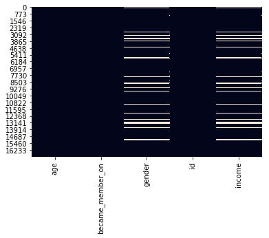

```python
sns.heatmap(profile.isnull(), cbar=False)
plt.show()
```

**Null values in 'gender' and 'income' and looks like they match**

```python
def distplot_plt(what_to_plot, plttitle, pltxlabel, pltylabel, pltxlim=100):
    fig= plt.subplots(figsize=(6,4))
    sns.distplot(what_to_plot, kde = False, bins=10, color = 'blue',
                 hist_kws={'edgecolor':'black'})
    plt.xlim(0, pltxlim)
    plt.xlim(left=-0.2)
    plt.title(plttitle,size = 20)
    plt.xlabel(pltxlabel, size =15)
    plt.ylabel(pltylabel, size =15)
    plt.show()
```

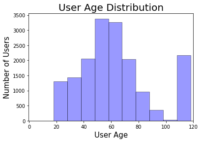

```python
# Lets check what is the age distribution

distplot_plt(profile.age,'User Age Distribution','User Age','Number of Users', 120)
```

**User age of 118 does not make sense. We need to check if this match with the rest of the Null and drop later**

```python
profile[profile["age"]==118].count()
```

```
age                 2175
became_member_on    2175
gender                 0
id                  2175
income                 0
dtype: int64
```

```python
profile[['age', 'gender', 'income']][profile["age"]==118].head(10)
```

|  | age | gender | income |
| --- | --- | --- | --- |
| 0 | 118 | None | NaN |
| 2 | 118 | None | NaN |
| 4 | 118 | None | NaN |
| 6 | 118 | None | NaN |
| 7 | 118 | None | NaN |
| 9 | 118 | None | NaN |
| 10 | 118 | None | NaN |
| 11 | 118 | None | NaN |
| 17 | 118 | None | NaN |
| 23 | 118 | None | NaN |

```python
print("~{}% is Missing Data so we can drop eventually later".format(round((2175*100)/17000), 2))
```

```
~13% is Missing Data so we can drop eventually later
```

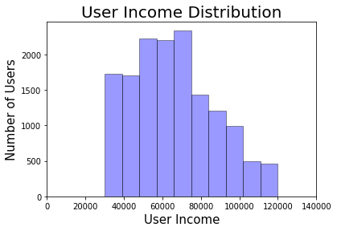

```python
distplot_plt(profile.income.dropna(),'User Income Distribution','User Income','Number of Users', 140000)
```

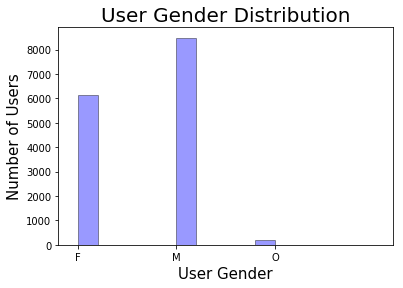

```python
distplot_plt(profile.gender.dropna(),'User Gender Distribution','User Gender','Number of Users', 3.2)
```

profile.json

- age (int) - age of the customer
- became_member_on (int) - date when customer created an app account
- gender (str) - gender of the customer (note some entries contain 'O' for other rather than M or F)
- id (str) - customer id
- income (float) - customer's income

**Null values in 'gender' and 'income' and looks like they match.**

**'became_member_on' will need to be re-engineered too.**

**User age of 118 does not make sense. I checked if this match with the rest of the Null and drop later. ~13% is Missing Data so we can drop eventually later.**

### Transcript - records for transactions, offers received, offers viewed, and offers completed

```python
transcript.head()
```

|  | event | person | time | value |
| --- | --- | --- | --- | --- |
| 0 | offer received | 78afa995795e4d85b5d9ceeca43f5fef | 0 | {'offer id': '9b98b8c7a33c4b65b9aebfe6a799e6d9'} |
| 1 | offer received | a03223e636434f42ac4c3df47e8bac43 | 0 | {'offer id': '0b1e1539f2cc45b7b9fa7c272da2e1d7'} |
| 2 | offer received | e2127556f4f64592b11af22de27a7932 | 0 | {'offer id': '2906b810c7d4411798c6938adc9daaa5'} |
| 3 | offer received | 8ec6ce2a7e7949b1bf142def7d0e0586 | 0 | {'offer id': 'fafdcd668e3743c1bb461111dcafc2a4'} |
| 4 | offer received | 68617ca6246f4fbc85e91a2a49552598 | 0 | {'offer id': '4d5c57ea9a6940dd891ad53e9dbe8da0'} |

```python
transcript.shape
```

```
(306534, 4)
```

```python
transcript['person'].nunique()
```

```
17000
```

```python
# Lets check for null values
transcript.isnull().sum()
```

```
event     0
person    0
time      0
value     0
dtype: int64
```

**Number of the unique Users on this dataset much with the number of Users in 'profile' and no Null values**

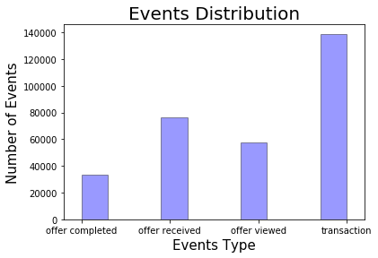

```python
distplot_plt(transcript.event.dropna(),'Events Distribution','Events Type','Number of Events', 3.2)
```

**transcript.json**

- event (str) - record description (ie transaction, offer received, offer viewed, etc.)
- person (str) - customer id
- time (int) - time in hours since start of test. The data begins at time t=0
- value - (dict of strings) - either an offer id or transaction amount depending on the record

**Number of the unique Users on this dataset much with the number of Users in 'profile' and no Null values.**

## Data preprocessing

#### Portfolio cleanup

```python
# Lets create from 'channels' nested list columns so we can eventually use later
all_channels = []
for channel in portfolio['channels']:
    for x in channel:
        if x not in all_channels:
            all_channels.append(x)

for i in all_channels:
    print('channel: {}'.format(i))
```

```
channel: email
channel: mobile
channel: social
channel: web
```

```python
# Creating all_channels columns
for channel in all_channels:
    portfolio[channel] = portfolio['channels'].apply(lambda x: 1 if channel in x else 0)

portfolio.head()
```

|  | channels | difficulty | duration | id | offer_type | reward | email | mobile | social | web |
| --- | --- | --- | --- | --- | --- | --- | --- | --- | --- | --- |
| 0 | [email, mobile, social] | 10 | 7 | ae264e3637204a6fb9bb56bc8210ddfd | bogo | 10 | 1 | 1 | 1 | 0 |
| 1 | [web, email, mobile, social] | 10 | 5 | 4d5c57ea9a6940dd891ad53e9dbe8da0 | bogo | 10 | 1 | 1 | 1 | 1 |
| 2 | [web, email, mobile] | 0 | 4 | 3f207df678b143eea3cee63160fa8bed | informational | 0 | 1 | 1 | 0 | 1 |
| 3 | [web, email, mobile] | 5 | 7 | 9b98b8c7a33c4b65b9aebfe6a799e6d9 | bogo | 5 | 1 | 1 | 0 | 1 |
| 4 | [web, email] | 20 | 10 | 0b1e1539f2cc45b7b9fa7c272da2e1d7 | discount | 5 | 1 | 0 | 0 | 1 |

```python
# Define column drop func due to multiple reuse will be needed

def drop_columns(drop_columns,df,inplace=False):
    '''
    inputs:
    - drop_cols: list or string of column name to be dropped
    - df: dataframe from which column should be dropped
    - inplace: specify whether columns are dropped in place or not

    outputs:
    - Returns dataframe with dropped columns.

    '''
    df=df.drop(columns=drop_columns,axis=1,inplace=True)
    return df
```

```python
drop_columns('channels', portfolio)
portfolio.head()
```

|  | difficulty | duration | id | offer_type | reward | email | mobile | social | web |
| --- | --- | --- | --- | --- | --- | --- | --- | --- | --- |
| 0 | 10 | 7 | ae264e3637204a6fb9bb56bc8210ddfd | bogo | 10 | 1 | 1 | 1 | 0 |
| 1 | 10 | 5 | 4d5c57ea9a6940dd891ad53e9dbe8da0 | bogo | 10 | 1 | 1 | 1 | 1 |
| 2 | 0 | 4 | 3f207df678b143eea3cee63160fa8bed | informational | 0 | 1 | 1 | 0 | 1 |
| 3 | 5 | 7 | 9b98b8c7a33c4b65b9aebfe6a799e6d9 | bogo | 5 | 1 | 1 | 0 | 1 |
| 4 | 20 | 10 | 0b1e1539f2cc45b7b9fa7c272da2e1d7 | discount | 5 | 1 | 0 | 0 | 1 |

#### Profile cleanup

```python
# Fill NA for 'gender' with Unknown
profile['gender'].fillna('Unknown', inplace = True)
profile.head()
```

|  | age | became_member_on | gender | id | income |
| --- | --- | --- | --- | --- | --- |
| 0 | 118 | 20170212 | Unknown | 68be06ca386d4c31939f3a4f0e3dd783 | NaN |
| 1 | 55 | 20170715 | F | 0610b486422d4921ae7d2bf64640c50b | 112000.0 |
| 2 | 118 | 20180712 | Unknown | 38fe809add3b4fcf9315a9694bb96ff5 | NaN |
| 3 | 75 | 20170509 | F | 78afa995795e4d85b5d9ceeca43f5fef | 100000.0 |
| 4 | 118 | 20170804 | Unknown | a03223e636434f42ac4c3df47e8bac43 | NaN |

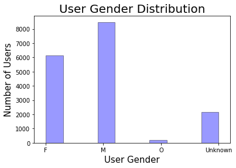

```python
distplot_plt(profile.gender.dropna(),'User Gender Distribution','User Gender','Number of Users', 3.2)
```

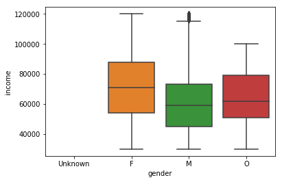

```python
plt.figure(figsize=(6,4))
sns.boxplot(x = 'gender', y = 'income', data = profile)
plt.show()
```

```python
profile["became_member_on"] =  pd.to_datetime(profile["became_member_on"], format='%Y%m%d')

profile.head()
```

|  | age | became_member_on | gender | id | income |
| --- | --- | --- | --- | --- | --- |
| 0 | 118 | 2017-02-12 | Unknown | 68be06ca386d4c31939f3a4f0e3dd783 | NaN |
| 1 | 55 | 2017-07-15 | F | 0610b486422d4921ae7d2bf64640c50b | 112000.0 |
| 2 | 118 | 2018-07-12 | Unknown | 38fe809add3b4fcf9315a9694bb96ff5 | NaN |
| 3 | 75 | 2017-05-09 | F | 78afa995795e4d85b5d9ceeca43f5fef | 100000.0 |
| 4 | 118 | 2017-08-04 | Unknown | a03223e636434f42ac4c3df47e8bac43 | NaN |

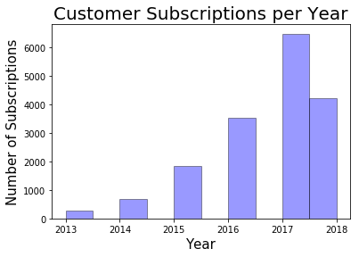

```python
# Lets explore customer subscriptions per month and year.

fig= plt.subplots(figsize=(6,4))
sns.distplot(profile["became_member_on"].dt.year, kde = False, bins=10, color = 'blue',
             hist_kws={'edgecolor':'black'})
plt.title('Customer Subscriptions per Year',size = 20)
plt.xlabel('Year', size =15)
plt.ylabel('Number of Subscriptions', size =15)
plt.show()
```

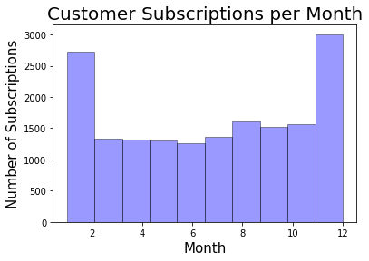

```python
fig= plt.subplots(figsize=(6,4))
sns.distplot(profile["became_member_on"].dt.month, kde = False, bins=10, color = 'blue',
             hist_kws={'edgecolor':'black'})
plt.title('Customer Subscriptions per Month',size = 20)
plt.xlabel('Month', size =15)
plt.ylabel('Number of Subscriptions', size =15)
plt.show()
```

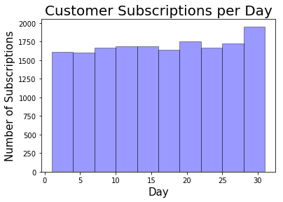

```python
fig= plt.subplots(figsize=(6,4))
sns.distplot(profile["became_member_on"].dt.day, kde = False, bins=10, color = 'blue',
             hist_kws={'edgecolor':'black'})
plt.title('Customer Subscriptions per Day',size = 20)
plt.xlabel('Day', size =15)
plt.ylabel('Number of Subscriptions', size =15)
plt.show()
```

#### Transcript cleanup

```python
#profile["became_member_on"].dt.month.value_counts().plot(kind = 'line', figsize = (10,10))
```

```python
# We have to exatract key/values form transcript['value'] column

transcript['key'] = transcript['value'].apply(lambda x: list(x.keys())[0])
transcript['value'] = transcript['value'].apply(lambda x: list(x.values())[0])
transcript['time'] = transcript['time'].apply(lambda x: int(x))

transcript.head()
```

|  | event | person | time | value | key |
| --- | --- | --- | --- | --- | --- |
| 0 | offer received | 78afa995795e4d85b5d9ceeca43f5fef | 0 | 9b98b8c7a33c4b65b9aebfe6a799e6d9 | offer id |
| 1 | offer received | a03223e636434f42ac4c3df47e8bac43 | 0 | 0b1e1539f2cc45b7b9fa7c272da2e1d7 | offer id |
| 2 | offer received | e2127556f4f64592b11af22de27a7932 | 0 | 2906b810c7d4411798c6938adc9daaa5 | offer id |
| 3 | offer received | 8ec6ce2a7e7949b1bf142def7d0e0586 | 0 | fafdcd668e3743c1bb461111dcafc2a4 | offer id |
| 4 | offer received | 68617ca6246f4fbc85e91a2a49552598 | 0 | 4d5c57ea9a6940dd891ad53e9dbe8da0 | offer id |

```python
transcript.dtypes
```

```
event     object
person    object
time       int64
value     object
key       object
dtype: object
```

```python
transcript.key.value_counts()
```

```
amount      138953
offer id    134002
offer_id     33579
Name: key, dtype: int64
```

```python
transcript['key'] = transcript['key'].str.replace('offer id','offer_id')
```

```python
transcript.key.value_counts()
```

```
offer_id    167581
amount      138953
Name: key, dtype: int64
```

```python
transcript['event'].value_counts()
```

```
transaction        138953
offer received      76277
offer viewed        57725
offer completed     33579
Name: event, dtype: int64
```

```python
transcript_new = transcript.groupby( [ "person", "event"] ).count().reset_index()
transcript_new.head()
```

|  | person | event | time | value | key |
| --- | --- | --- | --- | --- | --- |
| 0 | 0009655768c64bdeb2e877511632db8f | offer completed | 3 | 3 | 3 |
| 1 | 0009655768c64bdeb2e877511632db8f | offer received | 5 | 5 | 5 |
| 2 | 0009655768c64bdeb2e877511632db8f | offer viewed | 4 | 4 | 4 |
| 3 | 0009655768c64bdeb2e877511632db8f | transaction | 8 | 8 | 8 |
| 4 | 00116118485d4dfda04fdbaba9a87b5c | offer received | 2 | 2 | 2 |

```python
transcript[(transcript['event'] == 'offer completed')].head()
```

|  | event | person | time | value | key |
| --- | --- | --- | --- | --- | --- |
| 12658 | offer completed | 9fa9ae8f57894cc9a3b8a9bbe0fc1b2f | 0 | 2906b810c7d4411798c6938adc9daaa5 | offer_id |
| 12672 | offer completed | fe97aa22dd3e48c8b143116a8403dd52 | 0 | fafdcd668e3743c1bb461111dcafc2a4 | offer_id |
| 12679 | offer completed | 629fc02d56414d91bca360decdfa9288 | 0 | 9b98b8c7a33c4b65b9aebfe6a799e6d9 | offer_id |
| 12692 | offer completed | 676506bad68e4161b9bbaffeb039626b | 0 | ae264e3637204a6fb9bb56bc8210ddfd | offer_id |
| 12697 | offer completed | 8f7dd3b2afe14c078eb4f6e6fe4ba97d | 0 | 4d5c57ea9a6940dd891ad53e9dbe8da0 | offer_id |

```python
# Exploring offer which is 'offer received', 'offer viewed' and completed 'offer completed'

transcript[(transcript['person'] == '8f7dd3b2afe14c078eb4f6e6fe4ba97d')
           & (transcript['value'] == '4d5c57ea9a6940dd891ad53e9dbe8da0')]
```

|  | event | person | time | value | key |
| --- | --- | --- | --- | --- | --- |
| 227 | offer received | 8f7dd3b2afe14c078eb4f6e6fe4ba97d | 0 | 4d5c57ea9a6940dd891ad53e9dbe8da0 | offer_id |
| 12695 | offer viewed | 8f7dd3b2afe14c078eb4f6e6fe4ba97d | 0 | 4d5c57ea9a6940dd891ad53e9dbe8da0 | offer_id |
| 12697 | offer completed | 8f7dd3b2afe14c078eb4f6e6fe4ba97d | 0 | 4d5c57ea9a6940dd891ad53e9dbe8da0 | offer_id |

```python
# Checking copleted offer from the above cell
portfolio[portfolio['id'] == '4d5c57ea9a6940dd891ad53e9dbe8da0']
```

|  | difficulty | duration | id | offer_type | reward | email | mobile | social | web |
| --- | --- | --- | --- | --- | --- | --- | --- | --- | --- |
| 1 | 10 | 5 | 4d5c57ea9a6940dd891ad53e9dbe8da0 | bogo | 10 | 1 | 1 | 1 | 1 |

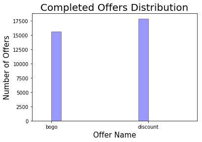

```python
# Ratio between copleted Offers

completed_offers_ratio = pd.merge(transcript[(transcript['key'] == 'offer_id') & (transcript['event'] == 'offer completed')]
                            , portfolio, how = 'inner', left_on = 'value', right_on = 'id')

distplot_plt(completed_offers_ratio['offer_type'],'Completed Offers Distribution','Offer Name','Number of Offers', 1.5)
```

```python
transcript.groupby(['event','key'])['key'].count()
```

```
event            key
offer completed  offer_id     33579
offer received   offer_id     76277
offer viewed     offer_id     57725
transaction      amount      138953
Name: key, dtype: int64
```

```python
# Create new DF from 'transcript' and 'portfolio' to Add the offer type
portfolio_new = portfolio[['offer_type', 'id']].copy()
portfolio_new.rename(columns={'id':'value'},inplace=True)

transcript_new=transcript.merge(portfolio_new,how='left',on='value')

transcript_new.head()
```

|  | event | person | time | value | key | offer_type |
| --- | --- | --- | --- | --- | --- | --- |
| 0 | offer received | 78afa995795e4d85b5d9ceeca43f5fef | 0 | 9b98b8c7a33c4b65b9aebfe6a799e6d9 | offer_id | bogo |
| 1 | offer received | a03223e636434f42ac4c3df47e8bac43 | 0 | 0b1e1539f2cc45b7b9fa7c272da2e1d7 | offer_id | discount |
| 2 | offer received | e2127556f4f64592b11af22de27a7932 | 0 | 2906b810c7d4411798c6938adc9daaa5 | offer_id | discount |
| 3 | offer received | 8ec6ce2a7e7949b1bf142def7d0e0586 | 0 | fafdcd668e3743c1bb461111dcafc2a4 | offer_id | discount |
| 4 | offer received | 68617ca6246f4fbc85e91a2a49552598 | 0 | 4d5c57ea9a6940dd891ad53e9dbe8da0 | offer_id | bogo |

```python
# Get count for each 'event' by type
transcript_new.groupby(['event','offer_type'])['event'].count()

# No offer Id for 'transaction'
```

```
event            offer_type
offer completed  bogo             15669
                 discount         17910
offer received   bogo             30499
                 discount         30543
                 informational    15235
offer viewed     bogo             25449
                 discount         21445
                 informational    10831
Name: event, dtype: int64
```

```python
transcript_new['event'].value_counts()
```

```
transaction        138953
offer received      76277
offer viewed        57725
offer completed     33579
Name: event, dtype: int64
```

```python
aa = transcript_new['event'].value_counts()
bb = transcript_new['event'].value_counts(normalize = True).mul(100)

pd.concat([aa,bb], axis=1, keys=['counts', '%'])
```

|  | counts | % |
| --- | --- | --- |
| transaction | 138953 | 45.330371 |
| offer received | 76277 | 24.883700 |
| offer viewed | 57725 | 18.831516 |
| offer completed | 33579 | 10.954413 |

```python
# list by %
ee = transcript_new.groupby(['event','offer_type'])['event'].count().rename("count")
ee / ee.groupby(level=0).sum() * 100
```

```
event            offer_type
offer completed  bogo             46.663093
                 discount         53.336907
offer received   bogo             39.984530
                 discount         40.042215
                 informational    19.973255
offer viewed     bogo             44.086618
                 discount         37.150282
                 informational    18.763101
Name: count, dtype: float64
```

**offer completed:**

- bogo 46.66 %
- discount 53.34 %

```python
# Get all transacttions per person
pd.options.mode.chained_assignment = None

def person_transactions_func(person):
    person_transactions = transcript[(transcript['person'] == person)
          & (transcript['key'] == 'amount')].reset_index()
    person_transactions['value'] = person_transactions['value'].copy().astype(float)
    person_transactions_mean = person_transactions.groupby('person').agg({'value':'mean'})

    return person_transactions , person_transactions_mean

person_transactions, person_transactions_mean = person_transactions_func('8f7dd3b2afe14c078eb4f6e6fe4ba97d')
person_transactions.head()
```

|  | index | event | person | time | value | key |
| --- | --- | --- | --- | --- | --- | --- |
| 0 | 12696 | transaction | 8f7dd3b2afe14c078eb4f6e6fe4ba97d | 0 | 19.11 | amount |
| 1 | 15605 | transaction | 8f7dd3b2afe14c078eb4f6e6fe4ba97d | 6 | 16.03 | amount |
| 2 | 29516 | transaction | 8f7dd3b2afe14c078eb4f6e6fe4ba97d | 48 | 14.24 | amount |
| 3 | 47598 | transaction | 8f7dd3b2afe14c078eb4f6e6fe4ba97d | 132 | 15.63 | amount |
| 4 | 51362 | transaction | 8f7dd3b2afe14c078eb4f6e6fe4ba97d | 156 | 23.48 | amount |

```python
person_transactions.describe()
```

|  | index | time | value |
| --- | --- | --- | --- |
| count | 8.00000 | 8.000000 | 8.000000 |
| mean | 87224.62500 | 201.000000 | 15.702500 |
| std | 92139.33753 | 215.642561 | 4.072215 |
| min | 12696.00000 | 0.000000 | 9.990000 |
| 25% | 26038.25000 | 37.500000 | 13.580000 |
| 50% | 49480.00000 | 144.000000 | 14.935000 |
| 75% | 111613.75000 | 279.000000 | 16.800000 |
| max | 268905.00000 | 594.000000 | 23.480000 |

```python
# How much average transactiion and how long have  per person is
person_transactions_mean
```

| person | value |
| --- | --- |
| 8f7dd3b2afe14c078eb4f6e6fe4ba97d | 15.7025 |

```python
transcript_new.head()
```

|  | event | person | time | value | key | offer_type |
| --- | --- | --- | --- | --- | --- | --- |
| 0 | offer received | 78afa995795e4d85b5d9ceeca43f5fef | 0 | 9b98b8c7a33c4b65b9aebfe6a799e6d9 | offer_id | bogo |
| 1 | offer received | a03223e636434f42ac4c3df47e8bac43 | 0 | 0b1e1539f2cc45b7b9fa7c272da2e1d7 | offer_id | discount |
| 2 | offer received | e2127556f4f64592b11af22de27a7932 | 0 | 2906b810c7d4411798c6938adc9daaa5 | offer_id | discount |
| 3 | offer received | 8ec6ce2a7e7949b1bf142def7d0e0586 | 0 | fafdcd668e3743c1bb461111dcafc2a4 | offer_id | discount |
| 4 | offer received | 68617ca6246f4fbc85e91a2a49552598 | 0 | 4d5c57ea9a6940dd891ad53e9dbe8da0 | offer_id | bogo |

```python
# Get promotions per Customer, joins person and offer id

def offer_completed_person(person):
    offer_completed = pd.merge(
                        transcript_new[transcript_new['event'] == 'offer received']
                        , transcript_new[transcript_new['event'] == 'offer completed']
                        , left_on = ['person','value']
                        , right_on = ['person','value']
                        , how = 'left')

    completed_offer_person  = offer_completed[offer_completed['person'] == person]

    return completed_offer_person

def offer_completed_all():
    completed_offer_all = pd.merge(
                        transcript_new[transcript_new['event'] == 'offer received']
                        , transcript_new[transcript_new['event'] == 'offer completed']
                        , left_on = ['person','value']
                        , right_on = ['person','value']
                        , how = 'left')

    return completed_offer_all
```

```python
offer_completed_person('a03223e636434f42ac4c3df47e8bac43')
```

|  | event_x | person | time_x | value | key_x | offer_type_x | event_y | time_y | key_y | offer_type_y |
| --- | --- | --- | --- | --- | --- | --- | --- | --- | --- | --- |
| 1 | offer received | a03223e636434f42ac4c3df47e8bac43 | 0 | 0b1e1539f2cc45b7b9fa7c272da2e1d7 | offer_id | discount | NaN | NaN | NaN | NaN |
| 28551 | offer received | a03223e636434f42ac4c3df47e8bac43 | 336 | 3f207df678b143eea3cee63160fa8bed | offer_id | informational | NaN | NaN | NaN | NaN |
| 43029 | offer received | a03223e636434f42ac4c3df47e8bac43 | 408 | 5a8bc65990b245e5a138643cd4eb9837 | offer_id | informational | NaN | NaN | NaN | NaN |
| 57555 | offer received | a03223e636434f42ac4c3df47e8bac43 | 504 | 0b1e1539f2cc45b7b9fa7c272da2e1d7 | offer_id | discount | NaN | NaN | NaN | NaN |
| 72013 | offer received | a03223e636434f42ac4c3df47e8bac43 | 576 | 0b1e1539f2cc45b7b9fa7c272da2e1d7 | offer_id | discount | NaN | NaN | NaN | NaN |

Looks like some people gets the same offer multiple times ^^

```python
offer_completed_person('78afa995795e4d85b5d9ceeca43f5fef')
```

|  | event_x | person | time_x | value | key_x | offer_type_x | event_y | time_y | key_y | offer_type_y |
| --- | --- | --- | --- | --- | --- | --- | --- | --- | --- | --- |
| 0 | offer received | 78afa995795e4d85b5d9ceeca43f5fef | 0 | 9b98b8c7a33c4b65b9aebfe6a799e6d9 | offer_id | bogo | offer completed | 132.0 | offer_id | bogo |
| 14258 | offer received | 78afa995795e4d85b5d9ceeca43f5fef | 168 | 5a8bc65990b245e5a138643cd4eb9837 | offer_id | informational | NaN | NaN | NaN | NaN |
| 43028 | offer received | 78afa995795e4d85b5d9ceeca43f5fef | 408 | ae264e3637204a6fb9bb56bc8210ddfd | offer_id | bogo | offer completed | 510.0 | offer_id | bogo |
| 57554 | offer received | 78afa995795e4d85b5d9ceeca43f5fef | 504 | f19421c1d4aa40978ebb69ca19b0e20d | offer_id | bogo | offer completed | 510.0 | offer_id | bogo |

```python
 offer_completed_person('0009655768c64bdeb2e877511632db8f')
```

|  | event_x | person | time_x | value | key_x | offer_type_x | event_y | time_y | key_y | offer_type_y |
| --- | --- | --- | --- | --- | --- | --- | --- | --- | --- | --- |
| 17397 | offer received | 0009655768c64bdeb2e877511632db8f | 168 | 5a8bc65990b245e5a138643cd4eb9837 | offer_id | informational | NaN | NaN | NaN | NaN |
| 31703 | offer received | 0009655768c64bdeb2e877511632db8f | 336 | 3f207df678b143eea3cee63160fa8bed | offer_id | informational | NaN | NaN | NaN | NaN |
| 46246 | offer received | 0009655768c64bdeb2e877511632db8f | 408 | f19421c1d4aa40978ebb69ca19b0e20d | offer_id | bogo | offer completed | 414.0 | offer_id | bogo |
| 60689 | offer received | 0009655768c64bdeb2e877511632db8f | 504 | fafdcd668e3743c1bb461111dcafc2a4 | offer_id | discount | offer completed | 528.0 | offer_id | discount |
| 75133 | offer received | 0009655768c64bdeb2e877511632db8f | 576 | 2906b810c7d4411798c6938adc9daaa5 | offer_id | discount | offer completed | 576.0 | offer_id | discount |

```python
# count of received offers per user
offer_completed_all().groupby(['person','event_x'])['person'].count().head(10)
```

```
person                            event_x
0009655768c64bdeb2e877511632db8f  offer received    5
00116118485d4dfda04fdbaba9a87b5c  offer received    2
0011e0d4e6b944f998e987f904e8c1e5  offer received    5
0020c2b971eb4e9188eac86d93036a77  offer received    7
0020ccbbb6d84e358d3414a3ff76cffd  offer received    4
003d66b6608740288d6cc97a6903f4f0  offer received    7
00426fe3ffde4c6b9cb9ad6d077a13ea  offer received    5
004b041fbfe44859945daa2c7f79ee64  offer received    3
004c5799adbf42868b9cff0396190900  offer received    9
005500a7188546ff8a767329a2f7c76a  offer received    5
Name: person, dtype: int64
```

```python
# count of completed offers per user
offer_completed_all().groupby(['person','event_y'])['person'].count().head(10)
```

```
person                            event_y
0009655768c64bdeb2e877511632db8f  offer completed    3
0011e0d4e6b944f998e987f904e8c1e5  offer completed    3
0020c2b971eb4e9188eac86d93036a77  offer completed    5
0020ccbbb6d84e358d3414a3ff76cffd  offer completed    3
003d66b6608740288d6cc97a6903f4f0  offer completed    5
00426fe3ffde4c6b9cb9ad6d077a13ea  offer completed    1
004b041fbfe44859945daa2c7f79ee64  offer completed    2
004c5799adbf42868b9cff0396190900  offer completed    9
005500a7188546ff8a767329a2f7c76a  offer completed    1
0056df74b63b4298809f0b375a304cf4  offer completed    3
Name: person, dtype: int64
```

```python
# count of total offers per user by type

offer_completed_all().groupby(['person','offer_type_x'])['person'].count().head(10)
```

```
person                            offer_type_x
0009655768c64bdeb2e877511632db8f  bogo             1
                                  discount         2
                                  informational    2
00116118485d4dfda04fdbaba9a87b5c  bogo             2
0011e0d4e6b944f998e987f904e8c1e5  bogo             1
                                  discount         2
                                  informational    2
0020c2b971eb4e9188eac86d93036a77  bogo             2
                                  discount         4
                                  informational    1
Name: person, dtype: int64
```

A person maight have multiple offers but did not coplete any of the even has transactions. Will try to find if there is a trend about the comleted offers

```python
# create Completed_Offer column
offer_completion= offer_completed_all()
offer_completion['Completed_Offer'] = offer_completion['event_y'].apply(lambda x: 0 if pd.isnull(x) == True else 1)
offer_completion.head()
```

|  | event_x | person | time_x | value | key_x | offer_type_x | event_y | time_y | key_y | offer_type_y | Completed_Offer |
| --- | --- | --- | --- | --- | --- | --- | --- | --- | --- | --- | --- |
| 0 | offer received | 78afa995795e4d85b5d9ceeca43f5fef | 0 | 9b98b8c7a33c4b65b9aebfe6a799e6d9 | offer_id | bogo | offer completed | 132.0 | offer_id | bogo | 1 |
| 1 | offer received | a03223e636434f42ac4c3df47e8bac43 | 0 | 0b1e1539f2cc45b7b9fa7c272da2e1d7 | offer_id | discount | NaN | NaN | NaN | NaN | 0 |
| 2 | offer received | e2127556f4f64592b11af22de27a7932 | 0 | 2906b810c7d4411798c6938adc9daaa5 | offer_id | discount | NaN | NaN | NaN | NaN | 0 |
| 3 | offer received | 8ec6ce2a7e7949b1bf142def7d0e0586 | 0 | fafdcd668e3743c1bb461111dcafc2a4 | offer_id | discount | NaN | NaN | NaN | NaN | 0 |
| 4 | offer received | 68617ca6246f4fbc85e91a2a49552598 | 0 | 4d5c57ea9a6940dd891ad53e9dbe8da0 | offer_id | bogo | NaN | NaN | NaN | NaN | 0 |

```python
completed_offer_df = pd.merge(offer_completion, portfolio, how = 'inner', left_on = 'value', right_on = 'id')[[
    'person','time_x','value','Completed_Offer', 'duration','offer_type','reward','difficulty', 'email',
    'mobile', 'social', 'web']]

completed_offer_df[completed_offer_df['person'] == '78afa995795e4d85b5d9ceeca43f5fef'].head()
```

|  | person | time_x | value | Completed_Offer | duration | offer_type | reward | difficulty | email | mobile | social | web |
| --- | --- | --- | --- | --- | --- | --- | --- | --- | --- | --- | --- | --- |
| 0 | 78afa995795e4d85b5d9ceeca43f5fef | 0 | 9b98b8c7a33c4b65b9aebfe6a799e6d9 | 1 | 7 | bogo | 5 | 5 | 1 | 1 | 0 | 1 |
| 50108 | 78afa995795e4d85b5d9ceeca43f5fef | 504 | f19421c1d4aa40978ebb69ca19b0e20d | 1 | 5 | bogo | 5 | 5 | 1 | 1 | 1 | 1 |
| 74434 | 78afa995795e4d85b5d9ceeca43f5fef | 408 | ae264e3637204a6fb9bb56bc8210ddfd | 1 | 7 | bogo | 10 | 10 | 1 | 1 | 1 | 0 |
| 80080 | 78afa995795e4d85b5d9ceeca43f5fef | 168 | 5a8bc65990b245e5a138643cd4eb9837 | 0 | 3 | informational | 0 | 0 | 1 | 1 | 1 | 0 |

```python
completed_offer_df['reward_value'] = completed_offer_df['reward'] - completed_offer_df['difficulty']
completed_offer_df[completed_offer_df['reward'] == 3].head()
```

|  | person | time_x | value | Completed_Offer | duration | offer_type | reward | difficulty | email | mobile | social | web | reward_value |
| --- | --- | --- | --- | --- | --- | --- | --- | --- | --- | --- | --- | --- | --- |
| 53106 | c4863c7985cf408faee930f111475da3 | 0 | 2298d6c36e964ae4a3e7e9706d1fb8c2 | 0 | 7 | discount | 3 | 7 | 1 | 1 | 1 | 1 | -4 |
| 53107 | 9f30b375d7bd4c62a884ffe7034e09ee | 0 | 2298d6c36e964ae4a3e7e9706d1fb8c2 | 1 | 7 | discount | 3 | 7 | 1 | 1 | 1 | 1 | -4 |
| 53108 | 2e87ba0fba1a4d1a8614af771f07a94d | 0 | 2298d6c36e964ae4a3e7e9706d1fb8c2 | 1 | 7 | discount | 3 | 7 | 1 | 1 | 1 | 1 | -4 |
| 53109 | 2e87ba0fba1a4d1a8614af771f07a94d | 0 | 2298d6c36e964ae4a3e7e9706d1fb8c2 | 1 | 7 | discount | 3 | 7 | 1 | 1 | 1 | 1 | -4 |
| 53110 | 8c7df0c393db488aac3e58b06a7ea5f9 | 0 | 2298d6c36e964ae4a3e7e9706d1fb8c2 | 1 | 7 | discount | 3 | 7 | 1 | 1 | 1 | 1 | -4 |

```python
completed_offer_df_all = completed_offer_df.groupby(['offer_type','difficulty','reward'], as_index = False).agg({
    'Completed_Offer':['mean', 'sum'], 'reward_value': 'max' })

completed_offer_df_all
```

|  | offer_type | difficulty | reward | Completed_Offer mean | Completed_Offer sum | reward_value max |
| --- | --- | --- | --- | --- | --- | --- |
| 0 | bogo | 5 | 5 | 0.670369 | 11891 | 0 |
| 1 | bogo | 10 | 10 | 0.555466 | 9659 | 0 |
| 2 | discount | 7 | 3 | 0.764465 | 7095 | -4 |
| 3 | discount | 10 | 2 | 0.707567 | 12848 | -8 |
| 4 | discount | 20 | 5 | 0.539798 | 4659 | -15 |
| 5 | informational | 0 | 0 | 0.000000 | 0 | 0 |

From the above output we can see that reward_value (i would probably get better name) what is better for Starbucks BOGO or Dicount

```python
transcript_new.head()
```

|  | event | person | time | value | key | offer_type |
| --- | --- | --- | --- | --- | --- | --- |
| 0 | offer received | 78afa995795e4d85b5d9ceeca43f5fef | 0 | 9b98b8c7a33c4b65b9aebfe6a799e6d9 | offer_id | bogo |
| 1 | offer received | a03223e636434f42ac4c3df47e8bac43 | 0 | 0b1e1539f2cc45b7b9fa7c272da2e1d7 | offer_id | discount |
| 2 | offer received | e2127556f4f64592b11af22de27a7932 | 0 | 2906b810c7d4411798c6938adc9daaa5 | offer_id | discount |
| 3 | offer received | 8ec6ce2a7e7949b1bf142def7d0e0586 | 0 | fafdcd668e3743c1bb461111dcafc2a4 | offer_id | discount |
| 4 | offer received | 68617ca6246f4fbc85e91a2a49552598 | 0 | 4d5c57ea9a6940dd891ad53e9dbe8da0 | offer_id | bogo |

```python
transcript.head()
```

|  | event | person | time | value | key |
| --- | --- | --- | --- | --- | --- |
| 0 | offer received | 78afa995795e4d85b5d9ceeca43f5fef | 0 | 9b98b8c7a33c4b65b9aebfe6a799e6d9 | offer_id |
| 1 | offer received | a03223e636434f42ac4c3df47e8bac43 | 0 | 0b1e1539f2cc45b7b9fa7c272da2e1d7 | offer_id |
| 2 | offer received | e2127556f4f64592b11af22de27a7932 | 0 | 2906b810c7d4411798c6938adc9daaa5 | offer_id |
| 3 | offer received | 8ec6ce2a7e7949b1bf142def7d0e0586 | 0 | fafdcd668e3743c1bb461111dcafc2a4 | offer_id |
| 4 | offer received | 68617ca6246f4fbc85e91a2a49552598 | 0 | 4d5c57ea9a6940dd891ad53e9dbe8da0 | offer_id |

```python
total_transactions = transcript[transcript['key'] == 'amount']

pd.options.mode.chained_assignment = None
total_transactions['value'] = total_transactions['value'].astype(float)

total_transactions.head()
```

|  | event | person | time | value | key |
| --- | --- | --- | --- | --- | --- |
| 12654 | transaction | 02c083884c7d45b39cc68e1314fec56c | 0 | 0.83 | amount |
| 12657 | transaction | 9fa9ae8f57894cc9a3b8a9bbe0fc1b2f | 0 | 34.56 | amount |
| 12659 | transaction | 54890f68699049c2a04d415abc25e717 | 0 | 13.23 | amount |
| 12670 | transaction | b2f1cd155b864803ad8334cdf13c4bd2 | 0 | 19.51 | amount |
| 12671 | transaction | fe97aa22dd3e48c8b143116a8403dd52 | 0 | 18.97 | amount |

Create a data set with all customer data in one place:

- 'person'
- 'gender'
- 'age'
- 'income'
- 'became_member_on'
- 'avg_transactions_amount'
- 'total_transactions_amount'
- 'total_transactions'
- 'avg_days_between_purchase'
- 'bogo_all_offers_received'
- 'bogo_all_offers_completed'
- 'bogo_average_reward
- 'discount_all_offers_received'
- 'discount_all_offers_completed'
- 'discount_average_reward'
- 'informational_offers'

```python
all_data_cols = ['person', 'gender', 'age', 'income', 'became_member_on', 'avg_transactions_amount',
                 'total_transactions_amount', 'total_transactions', 'avg_days_between_purchase',
                 'bogo_all_offers_received', 'bogo_all_offers_completed',
                 'bogo_average_reward', 'discount_all_offers_received', 'discount_all_offers_completed',
                 'discount_average_reward', 'informational_offers'
                ]

customers_all_together = pd.DataFrame(columns=['person', 'gender', 'age', 'income', 'became_member_on', 'avg_transactions_amount',
                 'total_transactions_amount', 'total_transactions', 'avg_days_between_purchase',
                 'bogo_all_offers_received', 'bogo_all_offers_completed',
                 'bogo_average_reward', 'discount_all_offers_received', 'discount_all_offers_completed',
                 'discount_average_reward', 'informational_offers'
                ])

customers_all_together
```

|  | person | gender | age | income | became_member_on | avg_transactions_amount | total_transactions_amount | total_transactions | avg_days_between_purchase | bogo_all_offers_received | bogo_all_offers_completed | bogo_average_reward | discount_all_offers_received | discount_all_offers_completed | discount_average_reward | informational_offers |
| --- | --- | --- | --- | --- | --- | --- | --- | --- | --- | --- | --- | --- | --- | --- | --- | --- |

```python
profile.head()
```

|  | age | became_member_on | gender | id | income |
| --- | --- | --- | --- | --- | --- |
| 0 | 118 | 2017-02-12 | Unknown | 68be06ca386d4c31939f3a4f0e3dd783 | NaN |
| 1 | 55 | 2017-07-15 | F | 0610b486422d4921ae7d2bf64640c50b | 112000.0 |
| 2 | 118 | 2018-07-12 | Unknown | 38fe809add3b4fcf9315a9694bb96ff5 | NaN |
| 3 | 75 | 2017-05-09 | F | 78afa995795e4d85b5d9ceeca43f5fef | 100000.0 |
| 4 | 118 | 2017-08-04 | Unknown | a03223e636434f42ac4c3df47e8bac43 | NaN |

```python
# numpy 1.13 + needed to run successfully the code below

for person in np.unique(profile['id']):

    # Customer demographics pewr individual
    person_data = profile[profile['id'] == person][['id', 'gender', 'age', 'income', 'became_member_on']]

    # Transactions info
    person_transaction = total_transactions[total_transactions['person'] == person].reset_index()
    if len(person_transaction) > 0:
        person_transaction['last_purchase_in_days'] = person_transaction.time.diff()
        person_transaction.iloc[0, -1] = person_transactions.loc[0, 'time']
        person_aggregated_trs = person_transaction.groupby('person', as_index = False).agg(
        {
            'time': ['count']
            , 'value': ['mean', 'sum']
            , 'last_purchase_in_days': ['mean']
        })
        # drop multy level colums
        person_aggregated_trs.columns = person_aggregated_trs.columns.droplevel(1)

        person_aggregated_trs.columns = ['person', 'total_transactions', 'avg_transaction_amount',
                                         'total_transactions_amount','avg_days_between_purchase'
                                        ]
    else:
        nan_array = [person, np.nan, np.nan, np.nan, np.nan]
        person_aggregated_trs = pd.DataFrame([nan_array]
                                         , columns = ['person', 'total_transactions', 'avg_transaction_amount',
                                                      'total_transactions_amount','avg_days_between_purchase'
                                                     ])

    personal_temp_df = pd.merge(person_data, person_aggregated_trs, how = 'inner', left_on = 'id', right_on = 'person')
    personal_temp_df.drop('id', axis = 1, inplace = True)


    for offer in ['discount','bogo']:
        globals()[offer + '_temp_df'] =  completed_offer_df[(completed_offer_df['person'] == person)
                       & (completed_offer_df['offer_type'] == offer)
                       ].groupby('person', as_index = False).agg({
                                                        'Completed_Offer':['count','sum']
                                                        , 'reward_value': ['mean']
                                                    })

        globals()[offer + '_temp_df'].columns = globals()[offer + '_temp_df'].columns.droplevel(1)
        globals()[offer + '_temp_df'].columns = [
                                        'person', offer + '_all_offers_received', offer + '_all_offers_completed',
                                        offer + '_average_reward']

        if len(globals()[offer + '_temp_df']) == 0:
            nan_array = [person,np.nan,np.nan,np.nan]
            globals()[offer + '_temp_df'] = globals()[offer + '_temp_df'].append(
                dict(zip(globals()[offer + '_temp_df'].columns, nan_array)), ignore_index=True)

    bogo_discounts_tmp = pd.merge(discount_temp_df, bogo_temp_df)
    bogo_discounts_tmp['informational_offers'] = len(completed_offer_df[(completed_offer_df['person'] == person)
                                                               & (completed_offer_df['offer_type'] == 'informational')])


    person_df_fin = pd.merge(personal_temp_df, bogo_discounts_tmp)

    customers_all_together = customers_all_together.append(person_df_fin)
```

```python
customers_all_together.head()
```

[output not shown]

```python
customers_all_together.to_csv('customers_all_together.csv')
```

```python
customers_all_together = pd.read_csv('customers_all_together.csv')
```

Will need to engineer the 'customers_all_together' newly created data frame for later use for using it for Clustering:

- column 'gender' is the only categorical column - need ot get_dummies for it
- lots on NaN and I will fill in with 0s

```python
df_columns = customers_all_together.columns.tolist()
```

```python
# will replace with NaN 118 as an invalid age first
customers_all_together.age = customers_all_together.age.replace(118, np.nan)

# fill with 0
customers_all_data = customers_all_together[['age',
 'avg_days_between_purchase',
 'avg_transaction_amount',
 'avg_transactions_amount',
 'bogo_all_offers_completed',
 'bogo_all_offers_received',
 'bogo_average_reward',
 'bogo_all_offers_completed',
 'discount_all_offers_completed',
 'discount_all_offers_received',
 'discount_average_reward',
 'discount_all_offers_completed',
 'gender',
 'income',
 'informational_offers',
 'total_transactions_amount',
 'total_transactions',
 'total_transactions_amount']].fillna(0)
```

```python
# Gender(categorical) creating dummies
customers_all_data = pd.get_dummies(data=customers_all_data, columns=['gender'])
customers_all_data.head()
```

|  | age | avg_days_between_purchase | avg_transaction_amount | avg_transactions_amount | bogo_all_offers_completed | bogo_all_offers_received | bogo_average_reward | bogo_all_offers_completed | discount_all_offers_completed | discount_all_offers_received | ... | discount_all_offers_completed | income | informational_offers | total_transactions_amount | total_transactions | total_transactions_amount | gender_F | gender_M | gender_O | gender_Unknown |
| --- | --- | --- | --- | --- | --- | --- | --- | --- | --- | --- | --- | --- | --- | --- | --- | --- | --- | --- | --- | --- | --- |
| 0 | 33.0 | 58.50 | 15.950000 | 0.0 | 1.0 | 1.0 | 0.0 | 1.0 | 2.0 | 2.0 | ... | 2.0 | 72000.0 | 2 | 127.60 | 8.0 | 127.60 | 0 | 1 | 0 | 0 |
| 1 | 0.0 | 60.00 | 1.363333 | 0.0 | 0.0 | 2.0 | 0.0 | 0.0 | 0.0 | 0.0 | ... | 0.0 | 0.0 | 0 | 4.09 | 3.0 | 4.09 | 0 | 0 | 0 | 1 |
| 2 | 40.0 | 104.40 | 15.892000 | 0.0 | 1.0 | 1.0 | 0.0 | 1.0 | 2.0 | 2.0 | ... | 2.0 | 57000.0 | 2 | 79.46 | 5.0 | 79.46 | 0 | 0 | 1 | 0 |
| 3 | 59.0 | 81.75 | 24.607500 | 0.0 | 1.0 | 2.0 | 0.0 | 1.0 | 4.0 | 4.0 | ... | 4.0 | 90000.0 | 1 | 196.86 | 8.0 | 196.86 | 1 | 0 | 0 | 0 |
| 4 | 24.0 | 52.50 | 12.837500 | 0.0 | 2.0 | 2.0 | 0.0 | 2.0 | 1.0 | 1.0 | ... | 1.0 | 60000.0 | 1 | 154.05 | 12.0 | 154.05 | 1 | 0 | 0 | 0 |

5 rows × 21 columns

```python
# Investigate for patterns in the amount of missing data in each column - we should not see.

((customers_all_data.isnull().sum()/customers_all_data.shape[0]*100).sort_values(ascending=False))
```

```
gender_Unknown                   0.0
discount_all_offers_received     0.0
avg_days_between_purchase        0.0
avg_transaction_amount           0.0
avg_transactions_amount          0.0
bogo_all_offers_completed        0.0
bogo_all_offers_received         0.0
bogo_average_reward              0.0
bogo_all_offers_completed        0.0
discount_all_offers_completed    0.0
discount_average_reward          0.0
gender_O                         0.0
discount_all_offers_completed    0.0
income                           0.0
informational_offers             0.0
total_transactions_amount        0.0
total_transactions               0.0
total_transactions_amount        0.0
gender_F                         0.0
gender_M                         0.0
age                              0.0
dtype: float64
```

```python
#customers_all_data.groupby('age').size()
```

## Implementation

At this point DF 'customers_all_data' is ready for the next step clustering. All customer data is in one Data Frame so we can use for investigation how specific cluster(group of Customers responds to different offer or combinations of offers). Earlier I filled with 0 all NaN so I can use all of the features. I will apply k-means clustering to the dataset and use the average within-cluster distances from each point to their assigned cluster's centroid to decide on a number of clusters to keep.

There are technically 4 Customers clusters based on their behaviour(this is the reason I choose 4)

- both offers - Bogo and Discount
- prefer Bogo over Discount
- prefer Discount over Bogo
- none of the offers

```python
# Check before if all columns are in correct type
customers_all_data.dtypes
```

```
age                              float64
avg_days_between_purchase        float64
avg_transaction_amount           float64
avg_transactions_amount          float64
bogo_all_offers_completed        float64
bogo_all_offers_received         float64
bogo_average_reward              float64
bogo_all_offers_completed        float64
discount_all_offers_completed    float64
discount_all_offers_received     float64
discount_average_reward          float64
discount_all_offers_completed    float64
income                           float64
informational_offers               int64
total_transactions_amount        float64
total_transactions               float64
total_transactions_amount        float64
gender_F                           uint8
gender_M                           uint8
gender_O                           uint8
gender_Unknown                     uint8
dtype: object
```

```python
# run k-means clustering on the data and...
# compute the average within-cluster distances.

def get_kmeans_score(data, center):
    '''
    returns the kmeans score regarding SSE for points to centers
    INPUT:
        data - the dataset you want to fit kmeans to
        center - the number of centers you want (the k value)
    OUTPUT:
        score - the SSE score for the kmeans model fit to the data
    '''
    #instantiate kmeans
    kmeans = KMeans(n_clusters=center)

    # Then fit the model to your data using the fit method
    model = kmeans.fit(data)

    # Obtain a score related to the model fit
    score = np.abs(model.score(data))

    return score

scores = []
centers = list(range(1,11))

for center in centers:
    scores.append(get_kmeans_score(customers_all_data, center))
```

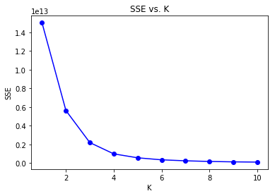

```python
# Investigate the change in within-cluster distance across number of clusters.
fig= plt.subplots(figsize=(6,4))
plt.plot(centers, scores, marker='o', color='b');
plt.xlabel('K');
plt.ylabel('SSE');
plt.title('SSE vs. K');
```

From the analisys of the above plot I do see a good visible elbow at 4 clusters. I choose to use Agglomerative Clustering (refference: https://chrisalbon.com/machine_learning/clustering/agglomerative_clustering/ https://stackabuse.com/hierarchical-clustering-with-python-and-scikit-learn/)

```python
# Create object
clt = AgglomerativeClustering(n_clusters=4, affinity='euclidean', linkage='ward')

# Train model
customers_all_together['cluster_num'] = clt.fit_predict(customers_all_data)
```

```python
customers_all_together.head()
```

|  | Unnamed: 0 | age | avg_days_between_purchase | avg_transaction_amount | avg_transactions_amount | became_member_on | bogo_all_offers_completed | bogo_all_offers_received | bogo_average_reward | discount_all_offers_completed | discount_all_offers_received | discount_average_reward | gender | income | informational_offers | person | total_transactions | total_transactions_amount | cluster_num |
| --- | --- | --- | --- | --- | --- | --- | --- | --- | --- | --- | --- | --- | --- | --- | --- | --- | --- | --- | --- |
| 0 | 0 | 33.0 | 58.50 | 15.950000 | NaN | 2017-04-21 | 1.0 | 1.0 | 0.0 | 2.0 | 2.0 | -8.0 | M | 72000.0 | 2 | 0009655768c64bdeb2e877511632db8f | 8.0 | 127.60 | 2 |
| 1 | 0 | NaN | 60.00 | 1.363333 | NaN | 2018-04-25 | 0.0 | 2.0 | 0.0 | NaN | NaN | NaN | Unknown | NaN | 0 | 00116118485d4dfda04fdbaba9a87b5c | 3.0 | 4.09 | 3 |
| 2 | 0 | 40.0 | 104.40 | 15.892000 | NaN | 2018-01-09 | 1.0 | 1.0 | 0.0 | 2.0 | 2.0 | -9.5 | O | 57000.0 | 2 | 0011e0d4e6b944f998e987f904e8c1e5 | 5.0 | 79.46 | 2 |
| 3 | 0 | 59.0 | 81.75 | 24.607500 | NaN | 2016-03-04 | 1.0 | 2.0 | 0.0 | 4.0 | 4.0 | -8.0 | F | 90000.0 | 1 | 0020c2b971eb4e9188eac86d93036a77 | 8.0 | 196.86 | 0 |
| 4 | 0 | 24.0 | 52.50 | 12.837500 | NaN | 2016-11-11 | 2.0 | 2.0 | 0.0 | 1.0 | 1.0 | -4.0 | F | 60000.0 | 1 | 0020ccbbb6d84e358d3414a3ff76cffd | 12.0 | 154.05 | 2 |

```python
customers_all_together.groupby('cluster_num').size()
```

```
cluster_num
0    4040
1    3781
2    7004
3    2175
dtype: int64
```

```python
# list by %
cluster_aa = customers_all_together['cluster_num'].value_counts()
cluster_bb = customers_all_together['cluster_num'].value_counts(normalize = True).mul(100)

pd.concat([cluster_aa,cluster_bb], axis=1, keys=['counts', '%'])
```

|  | counts | % |
| --- | --- | --- |
| 2 | 7004 | 41.200000 |
| 0 | 4040 | 23.764706 |
| 1 | 3781 | 22.241176 |
| 3 | 2175 | 12.794118 |

Cluster 2 has the most customers and 0,1 are almost equal

```python
customers_all_together.columns
```

```
Index(['Unnamed: 0', 'age', 'avg_days_between_purchase',
       'avg_transaction_amount', 'avg_transactions_amount', 'became_member_on',
       'bogo_all_offers_completed', 'bogo_all_offers_received',
       'bogo_average_reward', 'discount_all_offers_completed',
       'discount_all_offers_received', 'discount_average_reward', 'gender',
       'income', 'informational_offers', 'person', 'total_transactions',
       'total_transactions_amount', 'cluster_num'],
      dtype='object')
```

```python
def sns_pairplot_f(df, col_list):
    g = sns.pairplot(df[col_list].fillna(0),
                 hue='cluster_num',  palette='coolwarm', size=3.8)

    #plt.legend(title='Cluster', loc='upper left')
    plt.setp(g._legend.get_texts(), fontsize=18)
    plt.setp(g._legend.get_title(), fontsize=18)


    plt.tight_layout()
    plt.show()
```

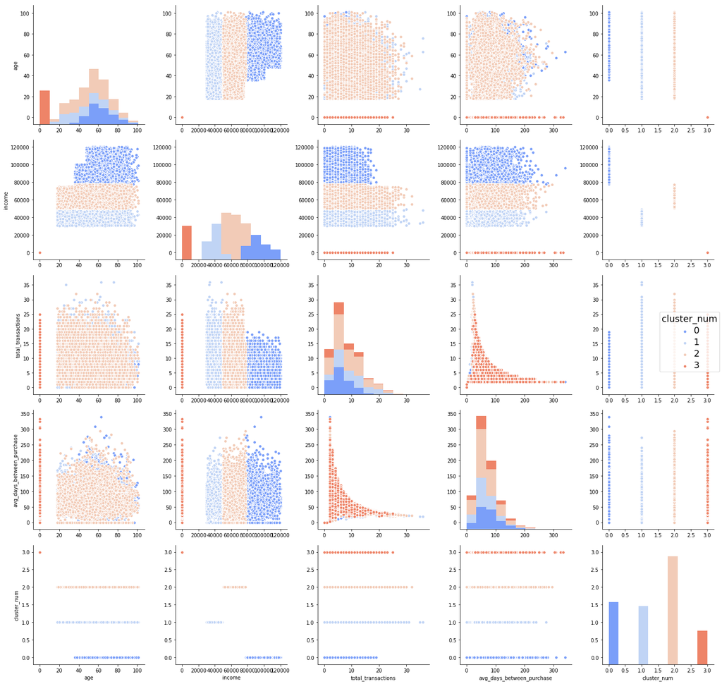

```python
# Lets explore Customers Demographics with pairplot
col_list_vis = ['age','income', 'total_transactions', 'avg_days_between_purchase' ,'cluster_num']
sns_pairplot_f(customers_all_together,col_list_vis)
```

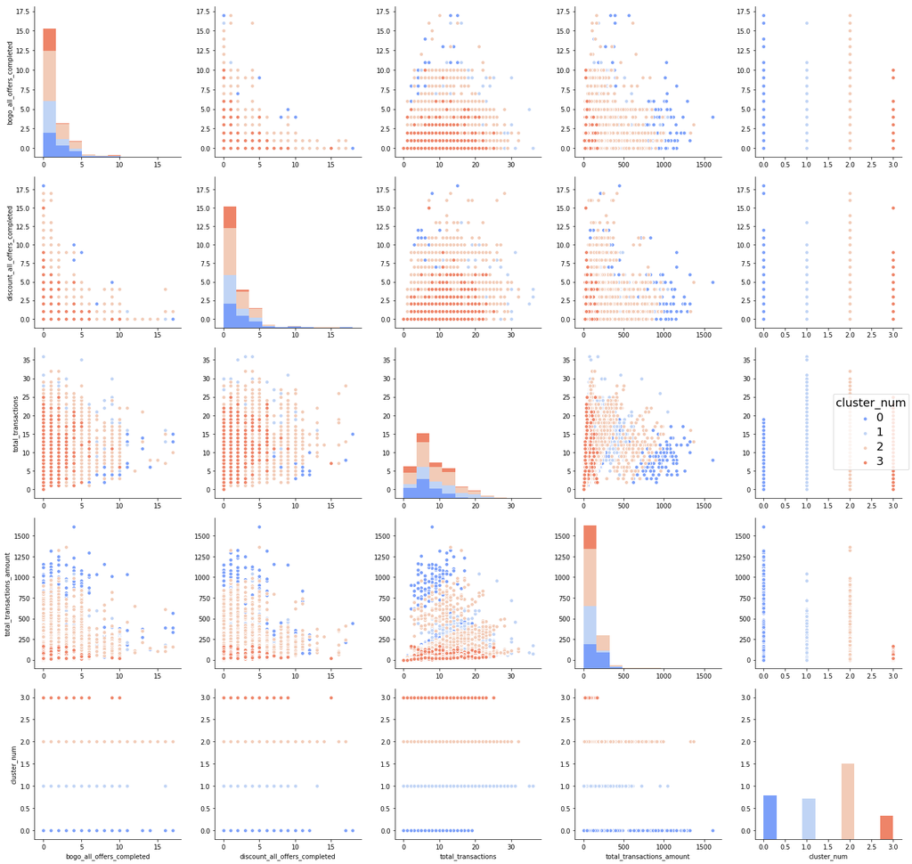

```python
# Lets explore reletaions to differnt offers
col_list_vis = ['bogo_all_offers_completed', 'discount_all_offers_completed', 'total_transactions',
       'total_transactions_amount', 'cluster_num']
sns_pairplot_f(customers_all_together,col_list_vis)
```

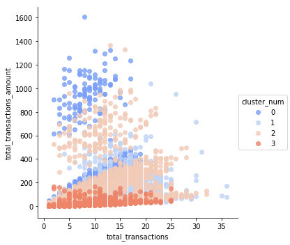

```python
plt.figure(figsize = (16,12))
sns.lmplot(x='total_transactions', y='total_transactions_amount', palette='coolwarm', hue='cluster_num'
           , data=customers_all_together, fit_reg=False);
```

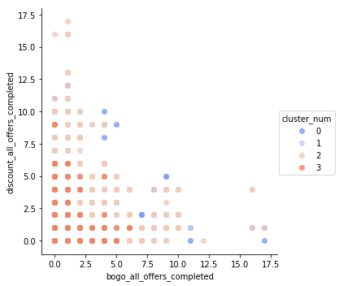

```python
plt.figure(figsize = (16,12))
sns.lmplot(x='bogo_all_offers_completed', y='discount_all_offers_completed', palette='coolwarm', hue='cluster_num'
           , data=customers_all_together, fit_reg=False);
```

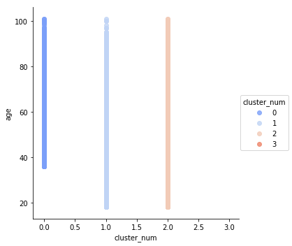

```python
plt.figure(figsize = (16,12))
sns.lmplot(x='cluster_num', y='age', palette='coolwarm', hue='cluster_num'
           , data=customers_all_together, fit_reg=False);
```

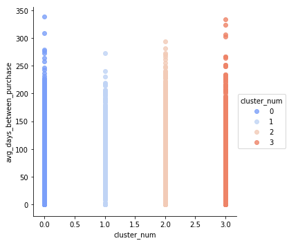

```python
plt.figure(figsize = (16,12))
sns.lmplot(x='cluster_num', y='avg_days_between_purchase', palette='coolwarm', hue='cluster_num'
           , data=customers_all_together, fit_reg=False);
```

```python
completed_offer_df_n = pd.merge(completed_offer_df, customers_all_together[['person','cluster_num']]).groupby(
                            ['cluster_num','offer_type','difficulty','reward']
                            , as_index = False ).agg({

     'Completed_Offer':['mean', 'sum']
    , 'reward_value': 'max'
})
```

```python
# distribution of offer per cluster
completed_offer_df_n = completed_offer_df_n[completed_offer_df_n['offer_type'] != 'informational']
completed_offer_df_n.columns.droplevel(1)
completed_offer_df_n.columns = ['cluster_num', 'offer_type', 'difficulty', 'reward', 'Completed_Offer_mean',
       'Completed_Offer_sum', 'reward_value']
```

```python
completed_offer_df_n
```

|  | cluster_num | offer_type | difficulty | reward | Completed_Offer_mean | Completed_Offer_sum | reward_value |
| --- | --- | --- | --- | --- | --- | --- | --- |
| 0 | 0 | bogo | 5 | 5 | 0.832012 | 3779 | 0 |
| 1 | 0 | bogo | 10 | 10 | 0.832997 | 3716 | 0 |
| 2 | 0 | discount | 7 | 3 | 0.872743 | 1982 | -4 |
| 3 | 0 | discount | 10 | 2 | 0.871309 | 3954 | -8 |
| 4 | 0 | discount | 20 | 5 | 0.813097 | 1788 | -15 |
| 6 | 1 | bogo | 5 | 5 | 0.597291 | 2293 | 0 |
| 7 | 1 | bogo | 10 | 10 | 0.364609 | 1329 | 0 |
| 8 | 1 | discount | 7 | 3 | 0.756109 | 1547 | -4 |
| 9 | 1 | discount | 10 | 2 | 0.627616 | 2459 | -8 |
| 10 | 1 | discount | 20 | 5 | 0.376582 | 714 | -15 |
| 12 | 2 | bogo | 5 | 5 | 0.728341 | 5330 | 0 |
| 13 | 2 | bogo | 10 | 10 | 0.622502 | 4548 | 0 |
| 14 | 2 | discount | 7 | 3 | 0.813818 | 3204 | -4 |
| 15 | 2 | discount | 10 | 2 | 0.761327 | 5831 | -8 |
| 16 | 2 | discount | 20 | 5 | 0.587368 | 2111 | -15 |
| 18 | 3 | bogo | 5 | 5 | 0.239823 | 489 | 0 |
| 19 | 3 | bogo | 10 | 10 | 0.033384 | 66 | 0 |
| 20 | 3 | discount | 7 | 3 | 0.352483 | 362 | -4 |
| 21 | 3 | discount | 10 | 2 | 0.295644 | 604 | -8 |
| 22 | 3 | discount | 20 | 5 | 0.048832 | 46 | -15 |

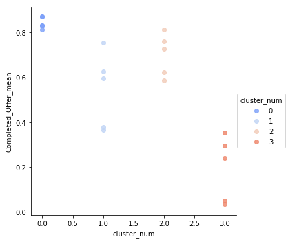

```python
plt.figure(figsize = (16,12))
sns.lmplot(x='cluster_num', y='Completed_Offer_mean', palette='coolwarm', hue='cluster_num'
           , data=completed_offer_df_n, fit_reg=False);
```

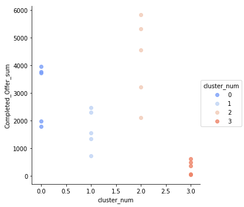

```python
plt.figure(figsize = (16,12))
sns.lmplot(x='cluster_num', y='Completed_Offer_sum', palette='coolwarm', hue='cluster_num'
           , data=completed_offer_df_n, fit_reg=False);
```

## Improvement

Final data frame "completed_offer_df_n" can be engineered more for example group by the clusters and sum the “Completed_Offer_mean” column for each cluster. Also “member since “ column can be added.

# ToDO:

Need to explore for better performance 'minibatchkmeans':

https://scikit-learn.org/stable/modules/generated/sklearn.cluster.MiniBatchKMeans.html

## Conclusion

After the analysis and using Machine Learning models offers can help Starbucks increasing the revenue but might not be really true for the profit. I also see a slow response rate. BOGO and discount shows better result than the Informational offers. Discount offers looks like a better choice first and if Customers do not respond BOGO should be the next step.

In Cluster_2 are most of the customers - 41.2%. Those are Customers will probably buy even without offer so might be not beneficial for Starbucks to sending to much offers to this group of people.

Discount offers has a higher response rate , and informational the lowest. Higher income people respond better to an offer and will more likely to spend more on Starbucks products.